# Schrute Paper

Annual West region summary

May 12, 2022

# 1 Schrute Paper West region annual summary

## 1.1 Industry and Schrute summary

We are Schrute Paper, the foremost purveyor of fine paper and paper accessories. At Schrute Paper, a Scranton, PA-based family-owned business since 1945, we search the world over for paper products from nitrogen-rich soils and bring those products to our customers with a zero-downtime guarantee.

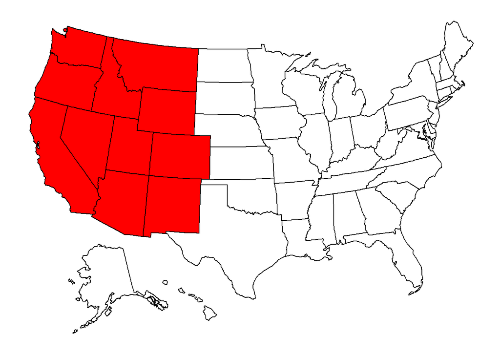

Figure 1.1: Schrute West region map.

## 1.2 Schrute Paper West region financial summary

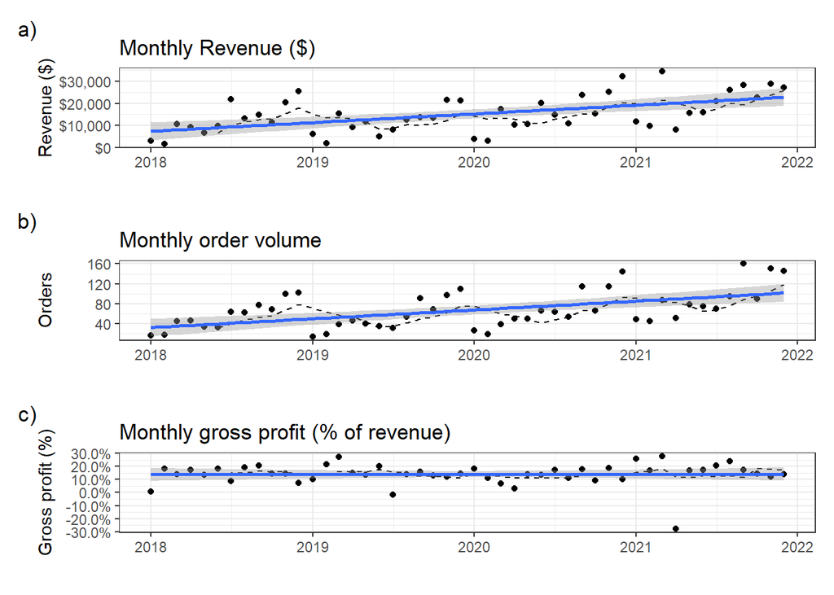

Figure 1.2: Sales trends for Schrute Paper West . Black points are monthly totals. The solid blue trendline is the simple (ordinary least squares) linear regression model of monthly averages. The gray band around the blue trendline shows the 95% confidence interval around model mean predictions. The dashed black line is the six-month moving average of monthly averages.

Schrute Paper West’s business is seasonal. Historically, our 4 month busy season, September through December, accounted for 52% of orders and 48% of revenue (Figure 1.2 a and b).

Schrute Paper West’s business grown over time. Since 2018, monthly mean revenue increased from $7,429 to $22,810. Monthly order volume matched this trend and increased from 32 orders in January 2018 to 101 orders in December 2021. Since 2018, monthly gross profit (as a percentage of revenue) remained relatively consistent seasonally and year-to-year at 14% (Figure 1.2 c).

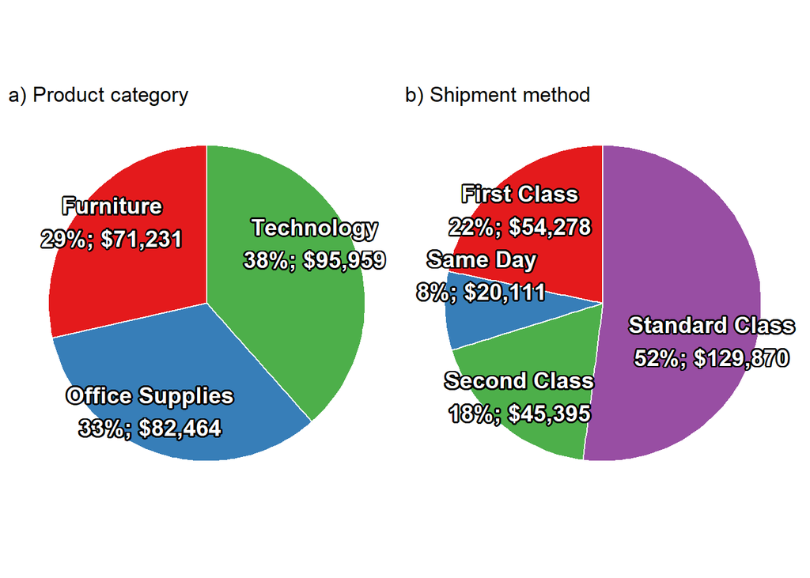

Figure 1.3: Schrute West region 2021 revenue by product category and shipment method.

Schrute Paper West’s 2021 revenue was not evenly distributed among product categories. Technology contributed the most revenue at 38% whereas Furniture contributed the least revenue at 29% (Figure 1.3 a).

Schrute Paper West’s 2021 revenue was not evenly distributed among shipment methods. Orders that shipped via Standard Class contributed the most revenue at 52% whereas orders that moved via Same Day contributed the least revenue at 8% (Figure 1.3 b).

*Table 1. Three largest profit and loss centers for Schrute Paper West in 2021.*

West region profit and cost centers

2021

| Customer | Per order Revenue | Per order Gross profit ($) | Per order Gross profit (%) | Annual totals Revenue | Annual totals Gross profit ($) | Annual totals Gross profit (%) | Annual totals Order Volume |
| --- | --- | --- | --- | --- | --- | --- | --- |
| Three largest cost centers |  |  |  |  |  |  |  |
| Sharelle Roach | $523 | −$685 | −131% | $2,613 | −$3,424 | −131% | 5 |
| Maris LaWare | $260 | −$97 | −37% | $1,299 | −$483 | −37% | 5 |
| Gary Hansen | $210 | −$159 | −76% | $631 | −$478 | −76% | 3 |
| Three largest profit centers |  |  |  |  |  |  |  |
| Raymond Buch | $4,684 | $2,245 | 48% | $14,052 | $6,734 | 48% | 3 |
| Jane Waco | $1,334 | $486 | 36% | $5,336 | $1,942 | 36% | 4 |
| Alan Dominguez | $871 | $307 | 35% | $4,353 | $1,536 | 35% | 5 |

Schrute Paper West’s 3 largest cost centers produced a loss of $4,385 in 2021 (Table 1). Sharelle Roach accounted for $-3,424 or 78% of this loss. Sharelle Roach’s orders produced an average loss of $-685 and -131%.

Schrute Paper West’s 3 largest profit centers earned the region a profit of $10,212 in 2021 (Table 1). Raymond Buch accounted for $6,734 or 66% of this profit. Raymond Buch’s orders produced an average profit of $2,245 and 48%.